# Sports Analytics - An Introduction in R

Yongqi Gan

## R and R Markdown

R is one of the most popular statistical programming languages. R is the only widely-used statistical programming language that is free and open source, with a wide developer community that contributes to the core language and corresponding packages. This file was created with RStudio, our recommended IDE for use with R. For more information and to download, see https://rstudio.com.

This is an R Markdown document generated by knitr and RStudio. Markdown is a simple formatting syntax for authoring HTML, PDF, and MS Word documents. For more details on using R Markdown see http://rmarkdown.rstudio.com.

## Loading Data

We are examining two datasets: The NBA player statistics and their historical salaries for the last 4 years.

Sources: https://stats.nba.com/ for performance data and https://hoopshype.com/salaries/players/ for salary data.

Let us first load the performance data into our R environment using the read.csv function. The `header = TRUE` flag tells the console that the first row of the file contains column names.

```r
players1819 <- read.csv(file = "players18-19.csv", header = TRUE)
players1718 <- read.csv(file = "players17-18.csv", header = TRUE)
players1617 <- read.csv(file = "players16-17.csv", header = TRUE)
players1516 <- read.csv(file = "players15-16.csv", header = TRUE)
```

and the salary data…

```r
salary1819 <- read.csv(file = "18-19_salary.csv", header = TRUE)
salary1718 <- read.csv(file = "17-18_salary.csv", header = TRUE)
salary1617 <- read.csv(file = "16-17_salary.csv", header = TRUE)
salary1516 <- read.csv(file = "15-16_salary.csv", header = TRUE)
```

## Cleaning Data

We will now merge the four dataframes for salary data and remove the individual datasets from our working environment. Note that we only include players that are accounted for in all four datasets to ensure consistency in our analysis.

```r
#merge concactenates two dataframes together by values in a certain row or column.
df_salary <- merge(salary1516, salary1617, by.x = "Player", by.y = "Player")
df_salary <- merge(df_salary, salary1718, by.x = "Player", by.y = "Player")
df_salary <- merge(df_salary, salary1819, by.x = "Player", by.y = "Player")

#rm removes dataframes and vectors from our local working environment.
#rm(salary1516, salary1617, salary1718, salary1819)
```

There are some issues with our data. If you click on the df_salary dataframe in the “environment” pane on the right, you will see that the year columns have weird names and that the dollar amounts are treated as factors. Factors are categorical variables best used to describe types of values (animals classified as “dog” “cat” etc.) This is undesirable for use in numerical data, and will impact any plotting or statistical analysis we want to do. Therefore, we will convert the factor vectors into numeric vectors and rename them using the code snippet below.

```r
names(df_salary) <- c("Player", "y1516", "y1617", "y1718", "y1819")

df_salary$Player <- as.character(df_salary$Player)

df_salary$y1516 = as.numeric(gsub("[\\$,]", "", as.character(df_salary$y1516)))
df_salary$y1617 = as.numeric(gsub("[\\$,]", "", as.character(df_salary$y1617)))
df_salary$y1718 = as.numeric(gsub("[\\$,]", "", as.character(df_salary$y1718)))
df_salary$y1819 = as.numeric(gsub("[\\$,]", "", as.character(df_salary$y1819)))

#Trim unnecessary whitespace to prevent string matching errors
df_salary$Player = trimws(df_salary$Player)
```

## Preliminary Analysis, Plotting, Data Visualization

We want to get an overview of the data in order to get an idea of how to consider analyzing it. We can start by simply viewing the header of the salary data, shown below.

```r
head(df_salary)
```

```
##            Player    y1516    y1617    y1718    y1819
## 1    Aaron Gordon  4405071  4549389  5662481 21590909
## 2      Al Horford 12671359 27748190 28530811 28928710
## 3    Al Jefferson 14255279 10695850 10050366  4000000
## 4 Al-Farouq Aminu  8492868  8030598  7529204  6957105
## 5   Alan Williams   120677   914448  6172292    77250
## 6      Alec Burks  9728947 10355341 11156939 11536515
```

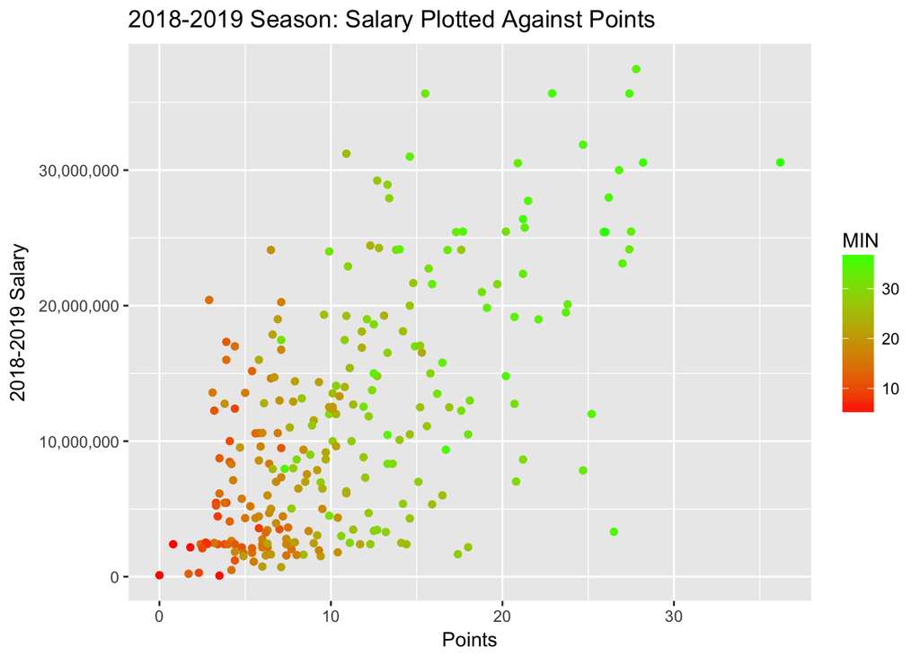

```r
require(ggplot2)
require(scales)
data1819 <- merge(df_salary, players1819, by.x = "Player", by.y = "PLAYER")

p <- ggplot(data = data1819, aes(y = y1819, x = PTS, colour = MIN))
p + scale_y_continuous(labels = comma) + ylab("2018-2019 Salary") +
  xlab("Points") + ggtitle("2018-2019 Season: Salary Plotted Against Points") +
  scale_color_gradient(low="red", high="green") + geom_point()
```

Interesting. We see that a higher salary is generally correlated with more scored points and more minutes played on average. This is likely an obvious observation to most of you, but it is helpful to see it confirmed graphically.

The visual examination leads us to believe that there is a positive relationship between salary and scored points. Let’s run a linear regression model to examine this numerically.

```r
#lm stands for "linear model"
points_salary <- lm(y1819 ~ PTS, data = data1819)
summary(points_salary)
```

```
##
## Call:
## lm(formula = y1819 ~ PTS, data = data1819)
##
## Residuals:
##       Min        1Q    Median        3Q       Max
## -21203611  -4704150   -789194   4028796  20410886
##
## Coefficients:
##             Estimate Std. Error t value Pr(>|t|)
## (Intercept)  2174352     830607   2.618  0.00938 **
## PTS           843156      65573  12.858  < 2e-16 ***
## ---
## Signif. codes:  0 '***' 0.001 '**' 0.01 '*' 0.05 '.' 0.1 ' ' 1
##
## Residual standard error: 6814000 on 254 degrees of freedom
## Multiple R-squared:  0.3943, Adjusted R-squared:  0.3919
## F-statistic: 165.3 on 1 and 254 DF,  p-value: < 2.2e-16
```

The original plot with our newly found regression line is displayed below.

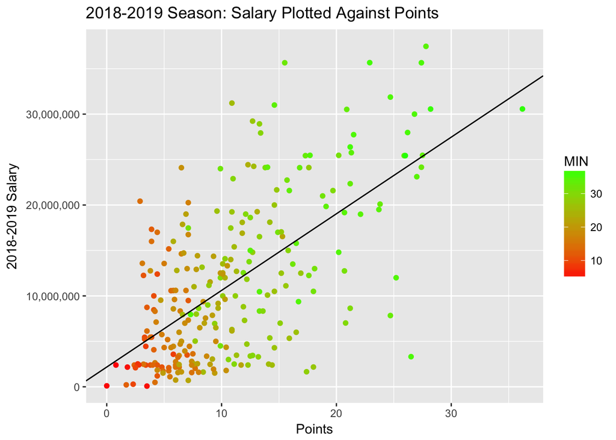

```r
p + scale_y_continuous(labels = comma) + ylab("2018-2019 Salary") +
  xlab("Points") + ggtitle("2018-2019 Season: Salary Plotted Against Points") +
  scale_color_gradient(low="red", high="green") + geom_point() + geom_abline(intercept = 2174352, slope = 843156)
```

## Optimization Example: Linear Programming

To demonstrate the power of R packages, let’s consider a hypothetical scenario: You are the manager of an NBA team. Your goal is to score at least 100 points every game on average, while spending as little as possible on the players’ salaries.

This is an optimization problem. We are trying to minimize a cost function (total salary cost), given a constraint (average at least 100 points). We can solve this optimization problem using a technique known as linear programming. For technical details you are welcome to review https://www.math.ucla.edu/~tom/LP.pdf; however, a technical understanding of the algorithm is not necessary for this example.

We will use a R package built by Michel Berkelaar, lpSolve, to solve this problem. R packages are custom-written libraries developed by statistians, companies, and other users to extend or the functionality of R or to simplify certain procedures.

```r
require(lpSolve)
# obj represents the objective function. This is the function that calculates the total cost of the team and is what we are trying to minimize.
obj <- data1819$y1819
#constr represents the constraint functions. These are the conditions that a valid solution must satisfy. The conditions we impose are that the "team" must have a minimum sum of 100 points per game, the team must have at least 12 players, and each player can only be chosen at most once.
constr <- matrix(append(append(data1819$PTS, rep(1, times = 256)), as.vector(diag(nrow = 256))), nrow = 258, byrow = TRUE)
#right represents the right hand side of the constraint functions.
right <- c(100, 12, rep(1, times = 256))
#constraints_direction represents the sign of the constraint functions.
constranints_direction  <- c(">=", ">=", rep("<=", times = 256))
optimum <-  lp(direction="min",
               objective.in = obj,
               const.mat = constr,
               const.dir = constranints_direction,
               const.rhs = right,
               all.int = T)

best_sol <- optimum$solution
names(best_sol) <- data1819$Player
print(best_sol)
```

```
##             Aaron Gordon               Al Horford          Al-Farouq Aminu
##                        0                        0                        0
##            Alan Williams               Alec Burks                 Alex Len
##                        1                        0                        0
##             Allen Crabbe             Amir Johnson           Andre Drummond
##                        0                        0                        0
##           Andre Iguodala             Andrew Bogut           Andrew Wiggins
##                        0                        1                        0
##            Anthony Davis         Anthony Tolliver              Aron Baynes
##                        0                        0                        0
##            Austin Rivers            Avery Bradley             Ben McLemore
##                        0                        0                        0
##          Bismack Biyombo            Blake Griffin         Boban Marjanovic
##                        0                        0                        0
##             Bobby Portis         Bojan Bogdanovic             Bradley Beal
##                        0                        0                        0
##           Brandon Knight              Brook Lopez            Bruno Caboclo
##                        0                        0                        1
##            Cameron Payne          Carmelo Anthony         Chandler Parsons
##                        0                        0                        0
##            Channing Frye               Chris Paul              CJ McCollum
##                        0                        0                        0
##                 CJ Miles             Clint Capela              Cody Zeller
##                        0                        0                        0
##             Corey Brewer              Cory Joseph             Courtney Lee
##                        1                        0                        0
##        Cristiano Felicio         D'Angelo Russell           Damian Lillard
##                        0                        0                        0
##         Danilo Gallinari              Danny Green         Dante Cunningham
##                        0                        0                        0
##               Dante Exum          Darren Collison           DeAndre Jordan
##                        0                        0                        0
##             Delon Wright            DeMar DeRozan         DeMarcus Cousins
##                        0                        0                        0
##          DeMarre Carroll           Derrick Favors             Derrick Rose
##                        0                        0                        1
##             Devin Booker             Devin Harris           Dewayne Dedmon
##                        1                        0                        0
##             Dion Waiters            Dirk Nowitzki           Doug McDermott
##                        0                        0                        0
```

[output cut: 117 more lines]

```
##                        0                        0                        0
##               Trey Lyles         Tristan Thompson             Troy Daniels
##                        0                        0                        0
##            Tyler Johnson             Tyler Zeller             Tyreke Evans
##                        0                        1                        0
##           Tyson Chandler               Tyus Jones            Udonis Haslem
##                        0                        0                        0
##           Victor Oladipo             Vince Carter          Wayne Ellington
##                        0                        0                        0
##           Wesley Johnson          Wesley Matthews              Will Barton
##                        0                        0                        0
##      Willie Cauley-Stein          Wilson Chandler              Zach LaVine
##                        0                        0                        0
##            Zaza Pachulia
##                        0
```

The players with a “1” under their name have been chosen for this “optimal” team.

```r
print(paste("Total cost: ", optimum$objval, sep=""))
```

```
## [1] "Total cost: 12387465"
```

We find that the total cost of this “optimal” team is 12.387 million dollars.

## Categorical Variable Analysis: Does switching teams increase expected salary?

It is widely understood in the professional basketball world that switching teams generally results in an increase in salary. We will now quantitatively test this hypothesis and determine the size of this effect.

First, we need to extract only the players who were active in the last 4 seasons:

```r
player <- merge(merge(merge(players1516[ , c("PLAYER", "TEAM")], players1617[ , c("PLAYER", "TEAM")], by = "PLAYER"), players1718[ , c("PLAYER", "TEAM")], by = "PLAYER"), players1819[ , c("PLAYER", "TEAM")], by = "PLAYER")
names(player) <- c("PLAYER", "TEAM1516", "TEAM1617", "TEAM1718", "TEAM1819")
```

Now we can count the number of times each player switched teams:

```r
player$switches <- 0
player$switches <- ifelse(player$TEAM1516 == player$TEAM1617, player$switches, player$switches + 1)
player$switches <- ifelse(player$TEAM1617 == player$TEAM1718, player$switches, player$switches + 1)
player$switches <- ifelse(player$TEAM1718 == player$TEAM1819, player$switches, player$switches + 1)
```

Let’s add the salary data to this dataset:

```r
player <- merge(player, df_salary, by.x = "PLAYER", by.y = "Player")
player2 <- player
player2$change <- player2$y1819 - player2$y1516
require(reshape)
player <- melt(player, id = c("PLAYER", "TEAM1516", "TEAM1617", "TEAM1718", "TEAM1819", "switches"))
```

We can create a plot of salaries based on the number of team switches:

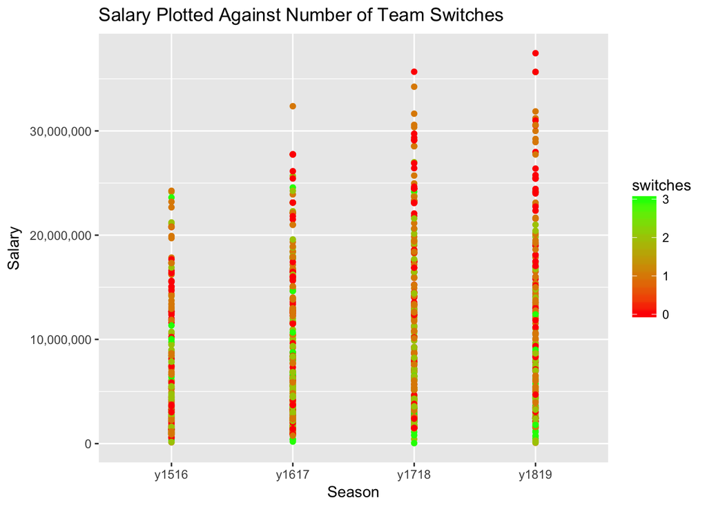

```r
p <- ggplot(data = player, aes(y = value, x = variable, colour = switches))
p + scale_y_continuous(labels = comma) + ylab("Salary") +
  xlab("Season") + ggtitle("Salary Plotted Against Number of Team Switches") +
  scale_color_gradient(low="red", high="green") + geom_point()
```

The graph doesn’t seem to be too promising on first glance. Let’s run a regression analysis on the change in salary across these four seasons given the change in teams:

```r
switch_lm <- lm(change ~ switches, data = player2)
summary(switch_lm)
```

```
##
## Call:
## lm(formula = change ~ switches, data = player2)
##
## Residuals:
##       Min        1Q    Median        3Q       Max
## -20935449  -4550918   -402481   4353721  18122651
##
## Coefficients:
##             Estimate Std. Error t value Pr(>|t|)
## (Intercept)  8427039     708532  11.894  < 2e-16 ***
## switches    -3266267     477605  -6.839 6.23e-11 ***
## ---
## Signif. codes:  0 '***' 0.001 '**' 0.01 '*' 0.05 '.' 0.1 ' ' 1
##
## Residual standard error: 6925000 on 247 degrees of freedom
## Multiple R-squared:  0.1592, Adjusted R-squared:  0.1558
## F-statistic: 46.77 on 1 and 247 DF,  p-value: 6.232e-11
```